# Using `mapcan` to create choropleth maps

Andrew McCormack

2019-01-05

## Description

The `mapcan()` function returns a data frame with geographic data that can be used in `ggplot2`.

## Overview

Visualizing spatial data in R often involves working with large, specialized shape files that require a fair amount of conversion and manipulation before they are ready for use in `ggplot`. `mapcan` has done most of the heavy lifting, providing flexible, `ggplot`-ready geographic data.

## Arguments

At the most basic level, `mapcan()` requires two arguments: `boundaries` and `type`.

By default, `mapcan()` will provide geographic data for the entire country. You may wish to either exclude the territories from your map or create a map of only one province:

- `province`: to produce geographic data for only one province (or territory), provide the `province` argument with a provincial alpha code (options are `NL`, `PE`, `NS`, `NB`, `QC`, `ON`, `MB`, `SK`, `AB`, `BC`, `YT`, `NT`, and `NU`). For example, setting `province = BC` will return geographic data only for British Columbia.
- `territories`: set `territories = FALSE` to exclude the territorities.

## Examples

### Creating a choropleth map with provincial boundaries

```r
mapcan(boundaries = province,
       type = standard) %>%
  head()
```

```
#>      long     lat order  hole piece pr_sgc_code group
#> 1 2278204 1261783     1 FALSE     1          10  10.1
#> 2 2277796 1259357     2 FALSE     1          10  10.1
#> 3 2280701 1259745     3 FALSE     1          10  10.1
#> 4 2283053 1257704     4 FALSE     1          10  10.1
#> 5 2288750 1255293     5 FALSE     1          10  10.1
#> 6 2294272 1251745     6 FALSE     1          10  10.1
#>                  pr_english               pr_french pr_alpha
#> 1 Newfoundland and Labrador Terre-Neuve-et-Labrador       NL
#> 2 Newfoundland and Labrador Terre-Neuve-et-Labrador       NL
#> 3 Newfoundland and Labrador Terre-Neuve-et-Labrador       NL
#> 4 Newfoundland and Labrador Terre-Neuve-et-Labrador       NL
#> 5 Newfoundland and Labrador Terre-Neuve-et-Labrador       NL
#> 6 Newfoundland and Labrador Terre-Neuve-et-Labrador       NL
```

`mapcan()` gives us a data frame with necessary components (longitude, latitude, order, hole, piece, and group) for use with `geom_polygon()` in the `ggplot` package. It also provides four different variables to describe the province that make it easy to merge this data with provincial data of your choice.

#### Basic ingredients for `ggplot`

To create a plot with data from `mapcan()`, the following aesthetic mappings are required: `x = long` (longitude), `y = lat` (latitude), `group = group` (this tells `geom_polygon()` how to group observations—in this case, provinces). Let’s initialize the plot:

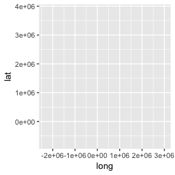

```r
pr_map <- mapcan(boundaries = province,
       type = standard) %>%
  ggplot(aes(x = long, y = lat, group = group))
pr_map
```

This doesn’t tell us much. We need to add a `geom` to visualize the map.

#### Using `geom_polygon` to plot the coordinates

To visualize the geographic data with `ggplot`, use `geom_polygon()`. It is important to also specify `coord_fixed()`—this fixes the relationship between longitude (the x-axis) and latitude (the y-axis):

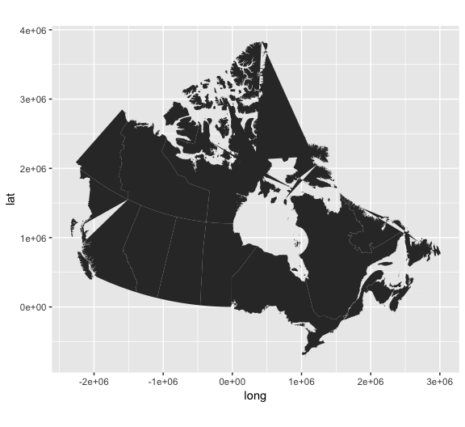

```r
pr_map <- pr_map +
  geom_polygon() +
  coord_fixed()
pr_map
```

You will notice that the axis text has no substantive significance. You can remove it, along with the axis ticks and background grid using `theme_mapcan` function, a `ggplot` theme that is part of the `mapcan` package:

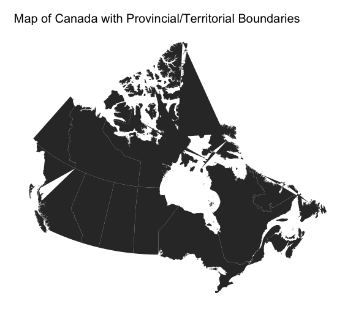

```r
pr_map +
  theme_mapcan() +
  ## Add a title
  ggtitle("Map of Canada with Provincial/Territorial Boundaries")
```

Though beautiful, this map is not very informative (unless you are unfamiliar with the shape of Canada). Let’s add some province-level data.

#### Incorporate province-level statistics

It is relatively straightforward to merge your own province-level statistics into the geographic data that `mapcan()` provides. To illustrate, we will work with the `province_pop_annual` data frame that is included in the `mapcan` package. This dataset provides annual provincial/territorial population estimates dating back to 1971. Let’s use the most recent population data, from 2017:

```r
pop_2017 <- mapcan::province_pop_annual %>%
  filter(year == 2017)

head(pop_2017)
```

```
#>   year                  province population
#> 1 2017                    Canada   36708083
#> 2 2017 Newfoundland and Labrador     528817
#> 3 2017      Prince Edward Island     152021
#> 4 2017               Nova Scotia     953869
#> 5 2017             New Brunswick     759655
#> 6 2017                    Quebec    8394034
```

The next step is to attach these numbers to every point on the polygons of the provinces. To do this, we first create the required geographic with `mapcan()`, then we use `inner_join()` from the `dplyr` package to merge in the `pop_2017` data:

```r
pr_geographic <- mapcan(boundaries = province,
       type = standard)


pr_geographic <- inner_join(pr_geographic,
           pop_2017,
           by = c("pr_english" = "province"))
```

To colour the provinces according to their population size, set the population variable as a `fill` aesthetic. Because population is a continuous variable (and because I don’t like the default colours), I will use `scale_fill_viridis_c()` colour scale to colour the map.

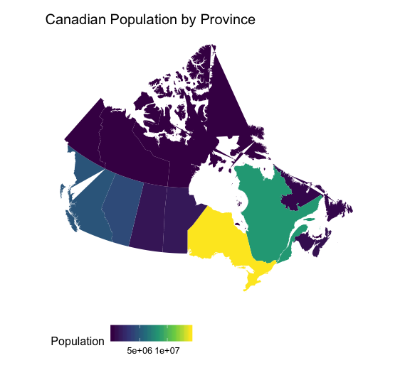

```r
pr_geographic %>%
  ggplot(aes(x = long, y = lat, group = group, fill = population)) +
  geom_polygon() +
  coord_fixed() +
  theme_mapcan() +
  scale_fill_viridis_c(name = "Population") +
  ggtitle("Canadian Population by Province")
```

### Creating a choropleth map with federal riding boundaries

#### Generate geographic data with riding boundaries

To create a map with federal riding boundaries, we specify `boundaries = ridings`. For the sake of illustration, let’s also look at just one province: British Columbia.

```r
bc_ridings <- mapcan(boundaries = ridings,
       type = standard,
       province = BC)

head(bc_ridings)
```

```
#>           long      lat order  hole piece riding_code   group
#> 20030 -1917601 428903.3 20030 FALSE     1       59001 59001.1
#> 20031 -1917311 426212.4 20031 FALSE     1       59001 59001.1
#> 20032 -1919423 421595.4 20032 FALSE     1       59001 59001.1
#> 20033 -1922364 417586.0 20033 FALSE     1       59001 59001.1
#> 20034 -1924519 416810.5 20034 FALSE     1       59001 59001.1
#> 20035 -1942173 424886.9 20035 FALSE     1       59001 59001.1
#>       riding_name_english riding_name_french pr_sgc_code       pr_english
#> 20030          Abbotsford         Abbotsford          59 British Columbia
#> 20031          Abbotsford         Abbotsford          59 British Columbia
#> 20032          Abbotsford         Abbotsford          59 British Columbia
#> 20033          Abbotsford         Abbotsford          59 British Columbia
#> 20034          Abbotsford         Abbotsford          59 British Columbia
#> 20035          Abbotsford         Abbotsford          59 British Columbia
#>                  pr_french pr_alpha centroid_long centroid_lat
#> 20030 Colombie-Britannique       BC      -1929376     423992.3
#> 20031 Colombie-Britannique       BC            NA           NA
#> 20032 Colombie-Britannique       BC            NA           NA
#> 20033 Colombie-Britannique       BC            NA           NA
#> 20034 Colombie-Britannique       BC            NA           NA
#> 20035 Colombie-Britannique       BC            NA           NA
```

#### Plot geographic data with riding boundaries

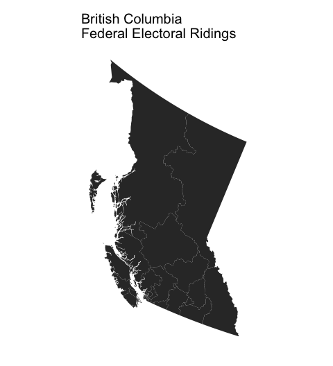

```r
ggplot(bc_ridings, aes(x = long, y = lat, group = group)) +
  geom_polygon() +
  coord_fixed() +
  theme_mapcan() +
  ggtitle("British Columbia \nFederal Electoral Ridings")
```

#### Incorporate riding-level statistics

Like with province-level statistics above, we can also merge our own riding-level statistics into the riding-level geographic data that `mapcan()` has produced. We will work with the `federal_election_results` data frame that is included in the `mapcan` package. This dataset provides federal election results for all elections dating back to 1997. We will use the results of 2015 federal election to colour the ridings in British Columbia.

*Note: At the moment, `mapcan()` only provides geographic data for the electoral boundaries (2013 Representation Order) of the 2015 federal election.*

```r
bc_results <- mapcan::federal_election_results %>%
  # Restrict data to include just 2015 election results from BC
  filter(election_year == 2015 & pr_alpha == "BC")

head(bc_results)
```

```
#>                     riding_name_english
#> 1                            Abbotsford
#> 2                Burnaby North--Seymour
#> 3                         Burnaby South
#> 4                Cariboo--Prince George
#> 5 Central Okanagan--Similkameen--Nicola
#> 6                      Chilliwack--Hope
#>                      riding_name_french riding_code population
#> 1                            Abbotsford       59001      96819
#> 2                Burnaby North--Seymour       59002     100632
#> 3                         Burnaby South       59003     105037
#> 4                Cariboo--Prince George       59004     108252
#> 5 Central Okanagan--Similkameen--Nicola       59005     104398
#> 6                      Chilliwack--Hope       59006      92734
#>   voter_turnout
```

[output cut: 27 more lines]

Next, we merge the two data frames (i.e. the geographic data and the election results data):

```r
bc_ridings <- inner_join(bc_results, bc_ridings, by = "riding_code")
```

To colour the ridings according the winning party of the 2015 election, set the `party` variable as a `fill` aesthetic:

```r
bc_riding_map <- bc_ridings %>%
  ggplot(aes(x = long, y = lat, group = group, fill = party)) +
  geom_polygon() +
  coord_fixed() +
  theme_mapcan() +
  ggtitle("British Columbia \n2015 Federal Electoral Results")
```

The colours are not ideal. We can easily provide our own custom colours that correspond to the colours associated with the different parties with `ggplot`’s `scale_fill_manual()`:

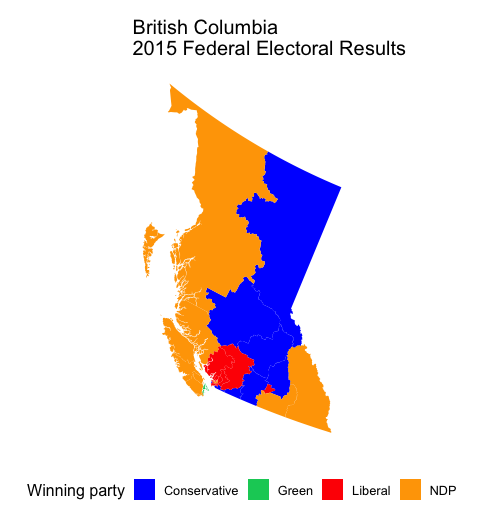

```r
bc_riding_map +
  scale_fill_manual(name = "Winning party",
                    values = c("blue", "springgreen3", "red", "Orange"))
```